# Lab6_Tianran

Tianran Zhang

7/13/2020

# Data import

**1. Set the seed to 252, import `RLab6_TMLE.csv`, assign it to dataframe `ObsData`, and assign the number of students in the data set to `n`.**

```r
set.seed(252)
ObsData <- read.csv("RLab6_TMLE.csv")
ObsData <- ObsData[, -1]
n <- nrow(ObsData)
```

**2. Explore the data set using the `summary`, `head`, and any other functions to help you understand the data. Only include code; do not evaluate this chunk of code when you turn in your assignment.**

```r
summary(ObsData)
head(ObsData)
sum(is.na(ObsData))
str(ObsData)
```

# Implement TMLE for the G-computation estimand

**3. Load the `SuperLearner` package. Then specify the Super Learner library with the following algorithms: `SL.glm`, `SL.step` and `SL.gam`.** In practice, we would want to use a larger library with a mixture of simple (e.g. parametric) and more aggressive libraries.

```r
SL.library <- c('SL.glm', 'SL.step', 'SL.gam')
```

**4. Use Super Learner to estimate $\mathrm{E}(Y|A, W)$, which is the expected reading comprehension difference given the exposure and baseline covariates.**

```r
# (a)
X1 <- X0 <- X <- ObsData[, c("A", "W1", "W2", "W3", "W4")]
X1$A <- 1
X0$A <- 0

# (b)
SL.outcome <- SuperLearner(Y = ObsData$Y, X = X,
                           SL.library = SL.library,
                           family = binomial)
SL.outcome
```

```
##
## Call:
## SuperLearner(Y = ObsData$Y, X = X, family = binomial, SL.library = SL.library)
##
##
##
##                   Risk Coef
## SL.glm_All  0.04682884    0
## SL.step_All 0.04659385    0
## SL.gam_All  0.01380903    1
```

```r
# (c)
m_AW <- predict(SL.outcome, newdata = ObsData)$pred

# (d)
m_1W <- predict(SL.outcome, newdata = X1)$pred

# (e)
m_0W <- predict(SL.outcome, newdata = X0)$pred


# (f)
theta.g <- mean(m_1W) - mean(m_0W)
```

The simple substitution estimator using Super Learner is 0.0784408.

**5. Estimate the exposure mechanism $g(W) = \mathrm{P}(A=1|W)$, which is the conditional probability of attending the program, given baseline covariates.**

```r
# (a)
SL_exposure <- SuperLearner(Y = ObsData$A, SL.library = SL.library,
                            X = dplyr::select(ObsData, -A, -Y),
                            family = binomial)

# (b)
g_W <- SL_exposure$SL.predict

summary(g_W)
```

```
##        V1
##  Min.   :0.1209
##  1st Qu.:0.7031
##  Median :0.7653
##  Mean   :0.7290
##  3rd Qu.:0.7880
##  Max.   :0.8118
```

```r
summary(1 - g_W)
```

```
##        V1
##  Min.   :0.1882
##  1st Qu.:0.2120
##  Median :0.2347
##  Mean   :0.2710
##  3rd Qu.:0.2969
##  Max.   :0.8791
```

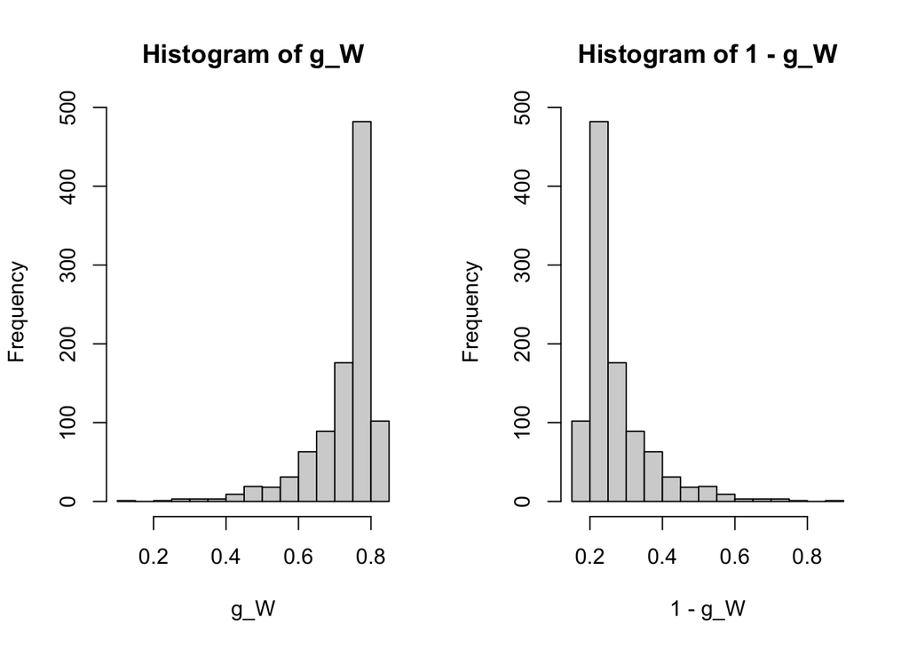

```r
par(mfrow = c(1, 2))
hist(g_W)
hist(1 - g_W)
```

**6. Use these estimates to create the clever covariate:**
$$\hat{H}(A, W) = \left(\frac{\mathrm{I}(A=1)}{\hat{g}(W)} - \frac{\mathrm{I}(A=0)}{1-\hat{g}(W)} \right)$$

```r
# (a)
H_AW <- ObsData$A/g_W - (1 - ObsData$A)/(1 - g_W)

# (b)
H_1W <- 1/g_W
H_0W <- 1/(1 - g_W)

# (c)
theta.iptw <- mean(ObsData$A/g_W * ObsData$Y) -
  mean((1 - ObsData$A)/(1 - g_W) * ObsData$Y)
```

The estimated iptw estimator is 0.0849454.

**7. Target the initial estimator of the conditional mean outcome $\hat{\mathrm{E}}(Y|A,W)$ with information in the estimated exposure mechanism $\hat{\mathrm{P}}(A=1|W)$.**

```r
# (a)
logit.update <- glm(ObsData$Y ~ -1 + offset(qlogis(m_AW)) + H_AW, family = binomial)
summary(logit.update)
```

```
##
## Call:
## glm(formula = ObsData$Y ~ -1 + offset(qlogis(m_AW)) + H_AW, family = binomial)
##
## Deviance Residuals:
##      Min        1Q    Median        3Q       Max
## -0.73245  -0.25680  -0.06386   0.16104   0.91674
##
## Coefficients:
##      Estimate Std. Error z value Pr(>|z|)
## H_AW -0.01254    0.03288  -0.381    0.703
##
## (Dispersion parameter for binomial family taken to be 1)
##
##     Null deviance: 83.159  on 1000  degrees of freedom
## Residual deviance: 83.014  on  999  degrees of freedom
## AIC: 846.06
##
## Number of Fisher Scoring iterations: 4
```

```r
# (b)
epsilon <- logit.update$coefficients

# (c)
m_AW_update <- plogis(qlogis(m_AW) + epsilon * H_AW)

# (d)
m_1W_update <- plogis(qlogis(m_1W) + epsilon * H_1W)
m_0W_update <- plogis(qlogis(m_0W) + epsilon * H_0W)
```

**8. Estimate the statistical parameter by substituting the targeted predictions into the G-Computation formula.**

```r
t <- m_1W_update - m_0W_update
```

We derived the estimator = 0.0841605 by substituting the targeted predictions into the G-Computation formula.

**9. Estimate $\theta$ by averaging the difference in the targeted predictions:**
$$\hat{\theta}_{TMLE} = \frac{1}{n} \sum_{i=1}^n \bigg[ \tilde{m}(A,W) \bigg]$$

```r
theta.tmle <- mean(m_1W_update) - mean(m_0W_update)
```

The TMLE estimator is 0.0841605.

**10. Compare with IPTW and the simple substitution results from earlier.**

```r
data.frame(method = c("IPTW", "TMLE", "G-computation"), estimator = c(theta.iptw, theta.tmle, theta.g))
```

```
##          method  estimator
## 1          IPTW 0.08494535
## 2          TMLE 0.08416051
## 3 G-computation 0.07844085
```

It seems the three etimators are very closed to each other.

# Variance estimation

## Using the influence curve

```r
tmle_se <- sd(H_AW *(ObsData$Y - m_AW_update) + m_1W_update - m_0W_update) / sqrt(n)
tmle_se
```

```
## [1] 0.008094237
```

The standard error of the TMLE estimator is 0.0080942.

**12. Briefly explain the background for this equation for the standard errors.**
The distribution of TMLE estimator is asymptotically linear:
$$\hat{\theta}_{tmle} - \theta \sim \frac{1}{n}\sum_{i = 1}^nD(O_i)$$
So, we have:
$$var(\theta.tmle) = var(D_P(O_i))/n$$
$$sd(\theta.tmle) = sd(D_P(O_i))/\sqrt{n}$$
Where,
$$D_P(O_i) = \frac{A_i}{\hat{g}(W_i)}[Y_i - \tilde{m}(W_i)] + \tilde{m}(W_i) - \hat{\theta}_{tmle}$$

## Implementing the non-parametric bootstrap

Alternatively, you could use the non-parametric bootstrap for variance estimation for statistical inference.

```r
B <- 50
estimates <- numeric(B)
for (i in 1:B){
  id <- sample(n, replace = T)
  dat <- ObsData[id, ]
  X1 <- X0 <- X <- dat[, c("A", "W1", "W2", "W3", "W4")]
  X1$A <- 1
  X0$A <- 0

  SL.outcome <- SuperLearner(Y = dat$Y, X = X,
                             SL.library = SL.library,
                             family = binomial)

  m_AW <- predict(SL.outcome, newdata = dat)$pred
  m_1W <- predict(SL.outcome, newdata = X1)$pred
  m_0W <- predict(SL.outcome, newdata = X0)$pred

  SL_exposure <- SuperLearner(Y = dat$A, SL.library = SL.library,
                            X = dplyr::select(dat, -A, -Y),
                            family = binomial)

  g_W <- SL_exposure$SL.predict

  H_AW <- dat$A/g_W - (1 - dat$A)/(1 - g_W)
  H_1W <- 1/g_W
  H_0W <- 1/(1 - g_W)

  logit.update <- glm(dat$Y ~ -1 + offset(qlogis(m_AW)) +
                        H_AW, family = binomial)
  epsilon <- logit.update$coefficients

  #m_AW_update <- plogis(qlogis(m_AW) + epsilon * H_AW)
  m_1W_update <- plogis(qlogis(m_1W) + epsilon * H_1W)
  m_0W_update <- plogis(qlogis(m_0W) + epsilon * H_0W)

  estimates[i] <- mean(m_1W_update - m_0W_update)
}
```

**14. Look at a histogram of the bootstrapped `estimates` and comment on your findings.**

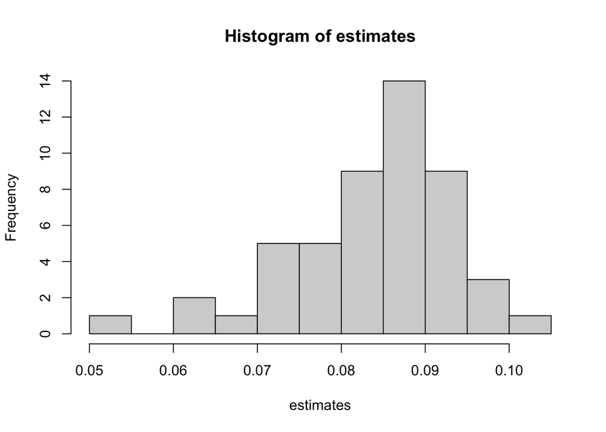

```r
hist(estimates)
```

**15. Assuming a normal distribution, compute a 95% confidence interval.**

```r
ci <- mean(estimates) + qnorm(c(.025, .975)) * sd(estimates)/sqrt(B)
```

The 95% CI is 0.0811107, 0.0865933 assuming a normal distribution.

**16. Using the `quantiles` function, find the 2.5% and 97.5% quantiles and use them to compute a 95% confidence interval for the point estimates.**

```r
ci.boot <- quantile(estimates, c(.025, .975))
```

The 95% CI is 0.0615383, 0.0966154 using the `quantiles` function.

# The basics of the `tmle` package

**17. Load the `tmle` package, read the documentation, then call the `tmle` function using Super Learner to estimate the conditional mean outcome $\mathrm{E}(Y|A,W)$ and the exposure mechanism $\mathrm{P}(A|W)$. Use the `summary` function to obtain point estimates and get inference.**

```r
fit.tmle <- tmle(Y = ObsData$Y, A = ObsData$A,
                 W = ObsData[, c("W1", "W2", "W3", "W4")],
                 Q.SL.library = SL.library,
                 g.SL.library = SL.library,
                 family = "binomial",
                 Qform = Y~ A + W1 + W2 + W3 + W4,
                 gform = A ~ W1 + W2 + W3 + W4)
summary(fit.tmle)
```

```
##  Initial estimation of Q
##   Procedure: cv-glm, user-supplied model
##   Cross-validated pseudo R squared :  0.0327
##
##  Estimation of g (treatment mechanism)
##   Procedure: user-supplied regression formula, ensemble   Empirical AUC = 0.5328
##
##   Model:
##       A ~  (Intercept) + W1 + W2 + W3 + W4
##
##   Coefficients:
##       (Intercept)    0.998041
##                W1    6.969988e-05
##                W2   -0.01382833
##                W3   -0.05400169
##                W4   -0.07169362
##
##  Estimation of g.Z (intermediate variable assignment mechanism)
##   Procedure: No intermediate variable
##
##  Estimation of g.Delta (missingness mechanism)
##   Procedure: No missingness, ensemble
##
##  Bounds on g: (0.0229, 1)
##
##  Bounds on g for ATT/ATE: (0.0229, 0.9771)
##
##  Additive Effect
##    Parameter Estimate:  0.14438
##    Estimated Variance:  0.00023121
##               p-value:  <2e-16
##     95% Conf Interval: (0.11458, 0.17418)
##
##  Additive Effect among the Treated
##    Parameter Estimate:  0.14637
##    Estimated Variance:  0.00024093
##               p-value:  <2e-16
##     95% Conf Interval: (0.11595, 0.17679)
##
##  Additive Effect among the Controls
##    Parameter Estimate:  0.13966
##    Estimated Variance:  0.00020793
##               p-value:  <2e-16
##     95% Conf Interval: (0.11139, 0.16792)
##
##  Relative Risk
##    Parameter Estimate:  1.764
##               p-value:  3.399e-15
##     95% Conf Interval: (1.5316, 2.0317)
##
##               log(RR):  0.5676
##     variance(log(RR)):  0.0051946
##
##  Odds Ratio
##    Parameter Estimate:  2.1461
##               p-value:  <2e-16
##     95% Conf Interval: (1.7944, 2.5666)
##
##               log(OR):  0.76364
##     variance(log(OR)):  0.0083363
```

**18. How do the estimates and confidence intervals from the TMLE function compare to your hand coded version with 1) the influence curve CIs and 2) the non-parametric bootstrap CIs?**

```r
# func.tmle <- fit.tmle$estimates$ATT$psi - fit.tmle$estimates$ATC$psi

data.frame(methods = c("tmle.func", "influence.curve", "non-para.boot"),
           estimator = c(fit.tmle$estimates$ATE$psi, theta.tmle, mean(estimates)),
           CI.l = c(fit.tmle$estimates$ATE$CI[1], theta.tmle + qnorm(.025) * tmle_se, ci.boot[1]),
           CI.u = c(fit.tmle$estimates$ATE$CI[2], theta.tmle + qnorm(.975) * tmle_se, ci.boot[2]))
```

```
##           methods  estimator       CI.l       CI.u
## 1       tmle.func 0.14438111 0.11457819 0.17418403
## 2 influence.curve 0.08416051 0.06829610 0.10002493
## 3   non-para.boot 0.08385202 0.06153831 0.09661541
```